# Checking Balance Improvement

Comparing days with one cruise vessels entering the port to days without. Adjusting for calendar and weather indicators.

In this document, we take great care providing all steps and R codes required to check whether our matching procedure allowed to improve covariates balance. We compare days where:

- treated units are days with one cruise vessel entering the port in *t*.
- control units are day with zero cruise vessel entering the port in *t*.

We adjust for calendar indicator and weather confouding factors.

**Should you have any questions, need help to reproduce the analysis or find coding errors, please do not hesitate to contact us at leo.zabrocki@psemail.eu and marion.leroutier@hhs.se.**

# Required Packages

To reproduce exactly the `5_script_checking_balance_improvement.html` document, we first need to have installed:

- the [R](https://www.r-project.org/) programming language
- [RStudio](https://rstudio.com/), an integrated development environment for R, which will allow you to knit the `5_script_checking_balance_figures.Rmd` file and interact with the R code chunks
- the [R Markdown](https://rmarkdown.rstudio.com/) package
- and the [Distill](https://rstudio.github.io/distill/) package which provides the template for this document.

Once everything is set up, we have to load the following packages:

```r
# load required packages
library(knitr) # for creating the R Markdown document
library(here) # for files paths organization
library(tidyverse) # for data manipulation and visualization
library(ggridges) # for ridge density plots
library(Cairo) # for printing customed police of graphs
library(patchwork) # combining plots
library(conflicted) # for dealing with packages' conflicts
conflict_prefer("select","dplyr")
conflict_prefer("filter","dplyr")
```

We finally load our customed `ggplot2` theme for graphs:

```r
# load ggplot customed theme
source(here::here("2.scripts", "5.custom_ggplot2_theme", "script_custom_ggplot_theme.R"))
```

The theme is based on the fantastic [hrbrthemes](https://hrbrmstr.github.io/hrbrthemes/index.html) package. If you do not want to use this theme or are unable to install it because of fonts issues, you can use the `theme_bw()` already included in the `ggplot2` package.

# Preparing the Data

We load the initial and matched data and bind them together:

```r
# load matching data
data_matching <- readRDS(here::here("1.data", "2.data_for_analysis", "1.cruise_experiment", "matching_data.rds")) %>%
    mutate(dataset = "Initial Data")

# load matched data
data_matched <- readRDS(here::here("1.data", "2.data_for_analysis", "1.cruise_experiment", "matched_data.rds")) %>%
    mutate(dataset = "Matched Data")

# bind the two datasets
data <- bind_rows(data_matching, data_matched)
```

We change labels of the `is_treated` variable :

```r
data <- data %>%
  mutate(is_treated = ifelse(is_treated == "TRUE", "True", "False"))
```

# Love Plots

### Continuous Weather Covariates

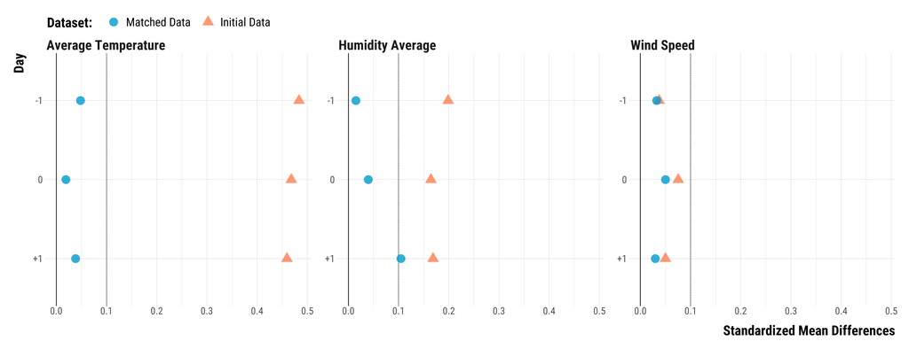

```r
# compute figures for the love plot
data_weather_continuous <- data %>%
  dplyr::select(dataset, is_treated, contains("temperature"), contains("humidity"), contains("wind_speed")) %>%
  pivot_longer(cols = -c(is_treated, dataset), names_to = "variable", values_to = "values") %>%
  mutate(weather_variable = NA %>%
           ifelse(str_detect(variable, "temperature_average"), "Average Temperature",.) %>%
           ifelse(str_detect(variable, "humidity_average"), "Humidity Average",.) %>%
           ifelse(str_detect(variable, "wind_speed"), "Wind Speed",.)) %>%
    mutate(time = "0" %>%
           ifelse(str_detect(variable, "lag_1"), "-1", .) %>%
           ifelse(str_detect(variable, "lead_1"), "+1", .)) %>%
  mutate(time = fct_relevel(time, "-1", "0", "+1")) %>%
  dplyr::select(dataset, is_treated, weather_variable, time, values)

data_abs_difference_continuous_weather <- data_weather_continuous %>%
  group_by(dataset, weather_variable, time, is_treated) %>%
  summarise(mean_values = mean(values, na.rm = TRUE)) %>%
  summarise(abs_difference = abs(mean_values[2]-mean_values[1]))

data_sd_weather_continuous <-  data_weather_continuous %>%
  filter(is_treated == "True") %>%
  group_by(dataset, weather_variable, time, is_treated) %>%
  summarise(sd_treatment = sd(values, na.rm = TRUE)) %>%
  ungroup() %>%
  dplyr::select(dataset, weather_variable, time, sd_treatment)

data_love_continuous_weather <- left_join(data_abs_difference_continuous_weather, data_sd_weather_continuous, by = c("dataset", "weather_variable", "time")) %>%
  mutate(standardized_difference = abs_difference/sd_treatment) %>%
  select(-c(abs_difference,sd_treatment))

# make the graph
graph_love_plot_continuous_weather <- ggplot(data_love_continuous_weather, aes(y = fct_rev(time), x = standardized_difference, colour = fct_rev(dataset), shape = fct_rev(dataset))) +
  geom_vline(xintercept = 0) +
  geom_vline(xintercept = 0.1, color = "black", linetype = "dashed") +
  geom_point(size = 8, alpha = 0.8) +
  scale_colour_manual(name = "Dataset:", values = c("deepskyblue3", "coral")) +
  scale_shape_manual(name = "Dataset:", values = c(16, 17)) +
  facet_wrap(~ weather_variable, scales = "free_y") +
  xlab("Standardized Mean Differences") +
  ylab("Day") +
  custom_theme +
  theme(
    legend.position = "top",
    legend.justification = "left",
    legend.direction = "horizontal",
    plot.margin = margin(1, 1, 1, 1, "cm"))

# plot the graph
graph_love_plot_continuous_weather
```

```r
# save the graph
ggsave(graph_love_plot_continuous_weather, filename = here::here("3.outputs", "1.figures", "2.analysis_pollution", "1.cruise_experiment", "1.checking_matching_procedure", "graph_love_plot_continuous_weather.pdf"),
       width = 50, height = 20, units = "cm", device = cairo_pdf)
```

### Categorical Weather Covariates

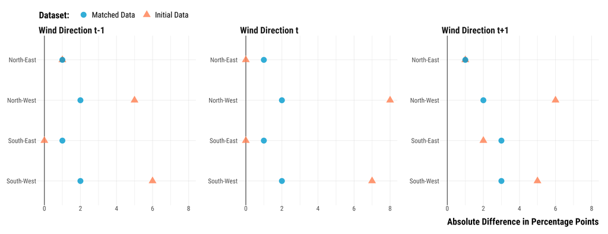

```r
# compute figures for the love plot
data_weather_categorical <- data %>%
  dplyr::select(dataset, is_treated, contains("rainfall_height_dummy"), contains("wind_direction_categories")) %>%
  mutate_at(vars(contains("rainfall")), ~ ifelse(.==1, "True", "False")) %>%
  mutate_all(~ as.character(.)) %>%
  pivot_longer(cols = -c(dataset, is_treated), names_to = "variable", values_to = "values") %>%
  # group by is_treated, variable and values
  group_by(dataset, is_treated, variable, values) %>%
  # compute the number of observations
  summarise(n = n()) %>%
  # compute the proportion
  mutate(freq = round(n / sum(n)*100, 0)) %>%
  ungroup() %>%
  mutate(weather_variable = NA %>%
           ifelse(str_detect(variable, "wind"), "Wind Direction",.) %>%
           ifelse(str_detect(variable, "rainfall"), "Rainfall Dummy",.)) %>%
  mutate(time = "t" %>%
           ifelse(str_detect(variable, "lag_1"), "t-1", .) %>%
           ifelse(str_detect(variable, "lead_1"), "t+1", .)) %>%
  filter(!is.na(time)) %>%
  mutate(variable = paste(weather_variable, time, sep = " ")) %>%
  dplyr::select(dataset, is_treated, weather_variable, variable, values, freq) %>%
  pivot_wider(names_from = is_treated, values_from = freq) %>%
  mutate(abs_difference = abs(`True` - `False`)) %>%
  filter(values != "False")

# create the figure for wind direction
graph_love_plot_wind_direction <- data_weather_categorical %>%
  filter(weather_variable == "Wind Direction") %>%
  mutate(variable = fct_relevel(variable, "Wind Direction t-1", "Wind Direction t", "Wind Direction t+1")) %>%
  ggplot(., aes(y = fct_rev(values), x = abs_difference, colour = fct_rev(dataset), shape = fct_rev(dataset))) +
  geom_vline(xintercept = 0) +
  geom_point(size = 8, alpha = 0.8) +
 scale_colour_manual(name = "Dataset:", values = c("deepskyblue3", "coral")) +
  scale_shape_manual(name = "Dataset:", values = c(16, 17)) +
  facet_wrap(~ variable, scales = "free_y", ncol = 3) +
  xlab("Absolute Difference in Percentage Points") +
  ylab("") +
  custom_theme +
  theme(
    legend.position = "top",
    legend.justification = "left",
    legend.direction = "horizontal",
    plot.margin = margin(1, 1, 1, -1, "cm"))

# print the figure for wind direction
graph_love_plot_wind_direction
```

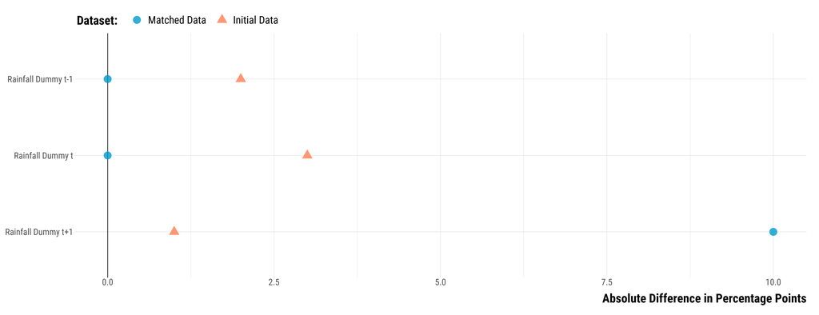

```r
# save the figure for wind direction
ggsave(graph_love_plot_wind_direction, filename = here::here("3.outputs", "1.figures", "2.analysis_pollution", "1.cruise_experiment", "1.checking_matching_procedure", "graph_love_plot_wind_direction.pdf"),
       width = 60, height = 30, units = "cm", device = cairo_pdf)

# create the figure for rainfall dummy
graph_love_plot_rainfall <- data_weather_categorical %>%
  filter(weather_variable == "Rainfall Dummy") %>%
  mutate(variable = fct_relevel(variable, "Rainfall Dummy t-1", "Rainfall Dummy t", "Rainfall Dummy t+1")) %>%
  ggplot(., aes(y = fct_rev(variable), x = abs_difference, colour = fct_rev(dataset), shape = fct_rev(dataset))) +
  geom_vline(xintercept = 0) +
  geom_point(size = 8, alpha = 0.8) +
 scale_colour_manual(name = "Dataset:", values = c("deepskyblue3", "coral")) +
  scale_shape_manual(name = "Dataset:", values = c(16, 17)) +
  xlab("Absolute Difference in Percentage Points") +
  ylab("") +
  custom_theme +
  theme(
    legend.position = "top",
    legend.justification = "left",
    legend.direction = "horizontal",
    plot.margin = margin(1, 1, 1, -1, "cm"))

# print the figure for rainfall dummy
graph_love_plot_rainfall
```

```r
# save the figure for rainfall dummy
ggsave(graph_love_plot_rainfall, filename = here::here("3.outputs", "1.figures", "2.analysis_pollution", "1.cruise_experiment", "1.checking_matching_procedure", "graph_love_plot_rainfall.pdf"),
       width = 30, height = 15, units = "cm", device = cairo_pdf)
```

### Pollutants

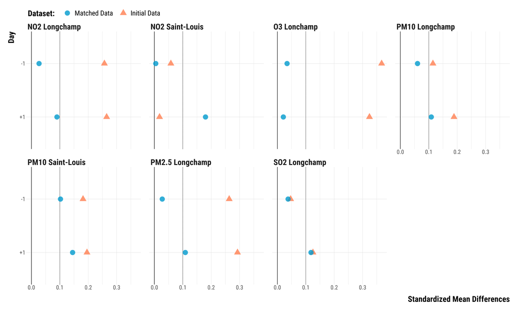

```r
# compute figures for the love plot
data_pollutants <- data %>%
  select(dataset, is_treated, contains("no2"), contains("o3"), contains("pm10"), contains("pm25"), contains("so2")) %>%
  pivot_longer(cols = -c(dataset, is_treated), names_to = "variable", values_to = "values") %>%
  mutate(pollutant = NA %>%
           ifelse(str_detect(variable, "no2_l"), "NO2 Longchamp",.) %>%
           ifelse(str_detect(variable, "no2_sl"), "NO2 Saint-Louis",.) %>%
           ifelse(str_detect(variable, "o3"), "O3 Lonchamp",.) %>%
           ifelse(str_detect(variable, "pm10_l"), "PM10 Longchamp",.) %>%
           ifelse(str_detect(variable, "pm10_sl"), "PM10 Saint-Louis",.) %>%
           ifelse(str_detect(variable, "pm25"), "PM2.5 Longchamp",.) %>%
           ifelse(str_detect(variable, "so2"), "SO2 Longchamp",.)) %>%
    mutate(time = NA %>%
           ifelse(str_detect(variable, "lag_1"), "-1", .) %>%
           ifelse(str_detect(variable, "lead_1"), "+1", .)) %>%
  filter(!is.na(time)) %>%
  dplyr::select(dataset, is_treated, pollutant, time, values)

data_abs_difference_pollutants <- data_pollutants %>%
  group_by(dataset, pollutant, time, is_treated) %>%
  summarise(mean_values = mean(values, na.rm = TRUE)) %>%
  summarise(abs_difference = abs(mean_values[2]-mean_values[1]))

data_sd_pollutants <-  data_pollutants %>%
  filter(is_treated == "True") %>%
  group_by(dataset, pollutant, time, is_treated) %>%
  summarise(sd_treatment = sd(values, na.rm = TRUE)) %>%
  ungroup() %>%
  dplyr::select(dataset, pollutant, time, sd_treatment)

data_love_pollutants <- left_join(data_abs_difference_pollutants, data_sd_pollutants, by = c("dataset", "pollutant", "time")) %>%
  mutate(standardized_difference = abs_difference/sd_treatment) %>%
  dplyr::select(-c(abs_difference,sd_treatment))

# create the graph
graph_love_plot_pollutants <- ggplot(data_love_pollutants, aes(y = fct_rev(time), x = standardized_difference, colour = fct_rev(dataset), shape = fct_rev(dataset))) +
  geom_vline(xintercept = 0) +
  geom_vline(xintercept = 0.1, color = "black", linetype = "dashed") +
  geom_point(size = 8, alpha = 0.8) +
 scale_colour_manual(name = "Dataset:", values = c("deepskyblue3", "coral")) +
  scale_shape_manual(name = "Dataset:", values = c(16, 17)) +
  facet_wrap(~ pollutant, ncol = 4) +
  xlab("Standardized Mean Differences") +
  ylab("Day") +
  custom_theme +
  theme(
    legend.position = "top",
    legend.justification = "left",
    legend.direction = "horizontal",
    plot.margin = margin(1, 1, 1, 1, "cm")
  )

# print the graph
graph_love_plot_pollutants
```

```r
# save the graph
ggsave(graph_love_plot_pollutants, filename = here::here("3.outputs", "1.figures", "2.analysis_pollution", "1.cruise_experiment", "1.checking_matching_procedure", "graph_love_plot_pollutants.pdf"),
       width = 60, height = 30, units = "cm", device = cairo_pdf)
```

### Vessel Traffic

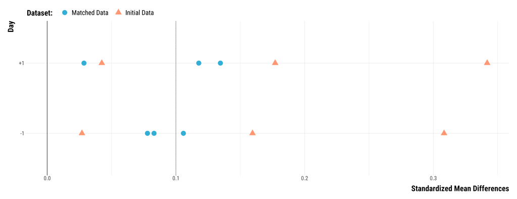

```r
# compute figures for the love plot
data_tonnage <-  data %>%
  # select relevant variables
  dplyr::select(dataset, is_treated, contains("total_gross_tonnage_cruise"),
         contains("total_gross_tonnage_ferry"), contains("total_gross_tonnage_other_boat")) %>%
  # transform data in long format
  pivot_longer(cols = -c(dataset, is_treated), names_to = "variable", values_to = "tonnage") %>%
  # create vessel type variable
  mutate(vessel_type = NA %>%
           ifelse(str_detect(variable, "cruise"), "Cruise",.) %>%
           ifelse(str_detect(variable, "ferry"), "Ferry",.) %>%
           ifelse(str_detect(variable, "other_boat"), "Other Types of Vessels",.)) %>%
  mutate(time = NA %>%
           ifelse(str_detect(variable, "lag_1"), "-1", .) %>%
           ifelse(str_detect(variable, "lead_1"), "+1", .)) %>%
  filter(!is.na(time)) %>%
  dplyr::select(dataset, vessel_type, is_treated, time, tonnage)

data_abs_difference_tonnage <- data_tonnage %>%
  group_by(dataset, vessel_type, time, is_treated) %>%
  summarise(mean_tonnage = mean(tonnage, na.rm = TRUE)) %>%
  summarise(abs_difference = abs(mean_tonnage[2]-mean_tonnage[1]))

data_sd_tonnage <-  data_tonnage %>%
  filter(is_treated == "True") %>%
  group_by(dataset, vessel_type, time, is_treated) %>%
  summarise(sd_treatment = sd(tonnage, na.rm = TRUE)) %>%
  ungroup() %>%
  dplyr::select(dataset, vessel_type, time, sd_treatment)

data_love_tonnage <- left_join(data_abs_difference_tonnage, data_sd_tonnage, by = c("dataset", "vessel_type", "time")) %>%
  mutate(standardized_difference = abs_difference/sd_treatment) %>%
  dplyr::select(-c(abs_difference,sd_treatment)) %>%
  filter(!(vessel_type == "Cruise" & time == 0))

# create the graph
graph_love_plot_tonnage <- ggplot(data_love_tonnage, aes(x = standardized_difference, y = as.factor(time), colour = fct_rev(dataset), shape = fct_rev(dataset))) +
  geom_vline(xintercept = 0) +
  geom_vline(xintercept = 0.1, color = "black", linetype = "dashed") +
  geom_point(size = 8, alpha = 0.8) +
 scale_colour_manual(name = "Dataset:", values = c("deepskyblue3", "coral")) +
  scale_shape_manual(name = "Dataset:", values = c(16, 17)) +
  xlab("Standardized Mean Differences") +
  ylab("Day") +
  custom_theme +
  theme(
    legend.position = "top",
    legend.justification = "left",
    legend.direction = "horizontal",
    plot.margin = margin(1, 1, 1, 1, "cm")
  )

# print the graph
graph_love_plot_tonnage
```

```r
# save the graph
ggsave(graph_love_plot_tonnage, filename = here::here("3.outputs", "1.figures", "2.analysis_pollution", "1.cruise_experiment", "1.checking_matching_procedure",
                                                      "graph_love_plot_tonnage.pdf"),
       width = 40, height = 20, units = "cm", device = cairo_pdf)
```

### Road Traffic

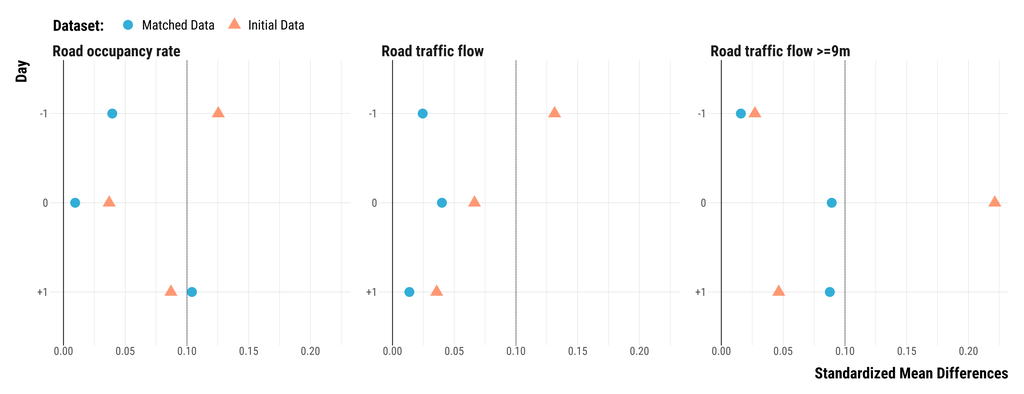

```r
# compute figures for the love plot
data_road<-  data %>%
  # select relevant variables
  dplyr::select(dataset, is_treated, contains("road_traffic_flow_all"),contains("road_occupancy_rate"),contains("road_traffic_flow_trucks"))%>%
  # transform data in long format
  pivot_longer(cols = -c(is_treated, dataset), names_to = "variable", values_to = "values") %>%
  mutate(road_traffic_variable = NA %>%
           ifelse(str_detect(variable, "trucks"), "Road traffic flow >=9m",.) %>%
           ifelse(str_detect(variable, "all"), "Road traffic flow",.) %>%
           ifelse(str_detect(variable, "occupancy"), "Road occupancy rate",.)) %>%
    mutate(time = "0" %>%
           ifelse(str_detect(variable, "lag_1"), "-1", .) %>%
           ifelse(str_detect(variable, "lead_1"), "+1", .)) %>%
  mutate(time = fct_relevel(time, "-1", "0", "+1")) %>%
  dplyr::select(dataset, is_treated,road_traffic_variable, time, values)


data_abs_difference_road <- data_road %>%
  group_by(dataset, road_traffic_variable, time, is_treated) %>%
  summarise(mean_values = mean(values, na.rm = TRUE)) %>%
  summarise(abs_difference = abs(mean_values[2]-mean_values[1]))

data_sd_road <-  data_road %>%
  filter(is_treated == "True") %>%
  group_by(dataset,road_traffic_variable, time, is_treated) %>%
  summarise(sd_treatment = sd(values, na.rm = TRUE)) %>%
  ungroup() %>%
  dplyr::select(dataset, road_traffic_variable, time, sd_treatment)


data_love_road <- left_join(data_abs_difference_road, data_sd_road, by = c("dataset", "road_traffic_variable", "time")) %>%
  mutate(standardized_difference = abs_difference/sd_treatment) %>%
  dplyr::select(-c(abs_difference,sd_treatment))

# make the graph
graph_love_plot_road <- ggplot(data_love_road, aes(y = fct_rev(time), x = standardized_difference, colour = fct_rev(dataset), shape = fct_rev(dataset))) +
  geom_vline(xintercept = 0) +
  geom_vline(xintercept = 0.1, color = "black", linetype = "dashed") +
  geom_point(size = 8, alpha = 0.8) +
  scale_colour_manual(name = "Dataset:", values = c("deepskyblue3", "coral")) +
  scale_shape_manual(name = "Dataset:", values = c(16, 17)) +
  facet_wrap(~ road_traffic_variable, scales = "free_y") +
  xlab("Standardized Mean Differences") +
  ylab("Day") +
  custom_theme +
  theme(
    legend.position = "top",
    legend.justification = "left",
    legend.direction = "horizontal",
    plot.margin = margin(1, 1, 1, 1, "cm"))

# plot the graph
graph_love_plot_road
```

```r
# save the graph
ggsave(graph_love_plot_road, filename = here::here("3.outputs", "1.figures", "2.analysis_pollution", "1.cruise_experiment", "1.checking_matching_procedure", "graph_love_plot_road_traffic.pdf"),
       width = 50, height = 20, units = "cm", device = cairo_pdf)
```

### Calendar Indicators

Create the relevant data:

```r
# compute figures for the love plot
data_calendar <- data %>%
  mutate(weekday = lubridate::wday(date, abbr = FALSE, label = TRUE)) %>%
  dplyr::select(dataset, is_treated, weekday, holidays_dummy, bank_day_dummy, month, year) %>%
  mutate_at(vars(holidays_dummy, bank_day_dummy), ~ ifelse(.==1, "True", "False")) %>%
  mutate_all(~ as.character(.)) %>%
  pivot_longer(cols = -c(dataset, is_treated), names_to = "variable", values_to = "values") %>%
  # group by is_treated, variable and values
  group_by(dataset, is_treated, variable, values) %>%
  # compute the number of observations
  summarise(n = n()) %>%
  # compute the proportion
  mutate(freq = round(n / sum(n)*100, 0)) %>%
  ungroup() %>%
  mutate(calendar_variable = NA %>%
           ifelse(str_detect(variable, "weekday"), "Day of the Week",.) %>%
           ifelse(str_detect(variable, "holidays_dummy"), "Holidays",.) %>%
           ifelse(str_detect(variable, "bank_day_dummy"), "Bank Day",.) %>%
           ifelse(str_detect(variable, "month"), "Month",.) %>%
           ifelse(str_detect(variable, "year"), "Year",.)) %>%
  dplyr::select(dataset, is_treated, calendar_variable, values, freq) %>%
  pivot_wider(names_from = is_treated, values_from = freq) %>%
  mutate(abs_difference = abs(`True` - `False`)) %>%
  filter(values != "False")
```

Plot for bank days and holidays:

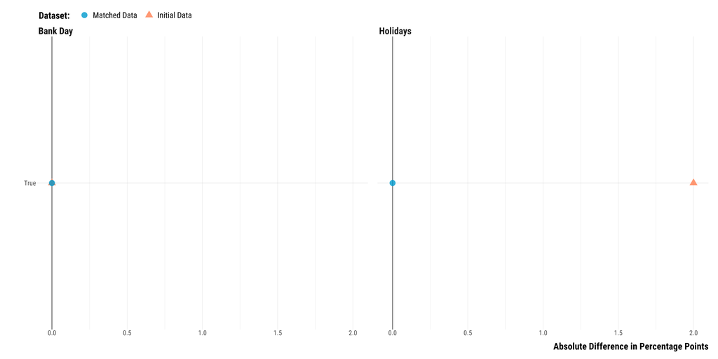

```r
# graph for bank days and holidays
graph_love_plot_bank_holidays <- data_calendar %>%
  filter(calendar_variable %in% c("Bank Day", "Holidays")) %>%
  ggplot(., aes(
    y = values,
    x = abs_difference,
    colour = fct_rev(dataset),
    shape = fct_rev(dataset)
  )) +
  geom_vline(xintercept = 0) +
  geom_point(size = 8, alpha = 0.8) +
 scale_colour_manual(name = "Dataset:", values = c("deepskyblue3", "coral")) +
  scale_shape_manual(name = "Dataset:", values = c(16, 17)) +
  facet_wrap( ~ calendar_variable) +
  xlab("Absolute Difference in Percentage Points") +
  ylab("") +
  custom_theme +
  theme(
    legend.position = "top",
    legend.justification = "left",
    legend.direction = "horizontal"
  )

# print the plot
graph_love_plot_bank_holidays
```

```r
# save the plot
ggsave(
  graph_love_plot_bank_holidays,
  filename = here::here(
    "3.outputs",
    "1.figures",
    "2.analysis_pollution",
    "1.cruise_experiment",
    "1.checking_matching_procedure",
    "graph_love_plot_bank_holidays.pdf"
  ),
  width = 30,
  height = 20,
  units = "cm",
  device = cairo_pdf
)
```

Plot for days of the week:

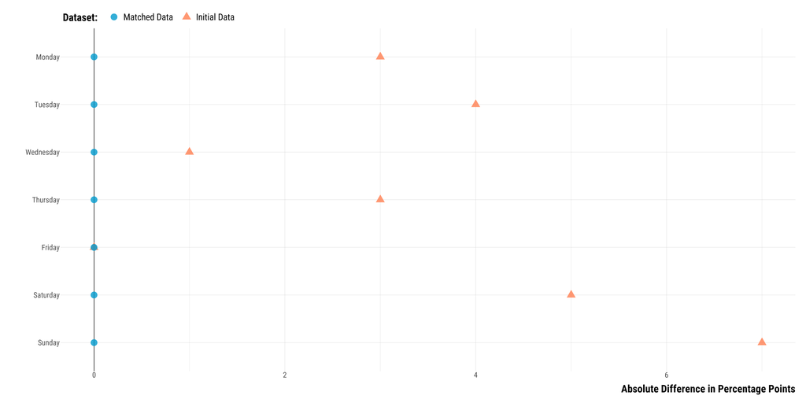

```r
# graph for weekdays
graph_love_plot_weekday <- data_calendar %>%
  filter(calendar_variable == "Day of the Week") %>%
  mutate(
    values = fct_relevel(
      values,
      "Monday",
      "Tuesday",
      "Wednesday",
      "Thursday",
      "Friday",
      "Saturday",
      "Sunday"
    )
  ) %>%
  ggplot(., aes(
    y = fct_rev(values),
    x = abs_difference,
    colour = fct_rev(dataset),
    shape = fct_rev(dataset)
  )) +
  geom_vline(xintercept = 0) +
  geom_point(size = 8, alpha = 0.8) +
 scale_colour_manual(name = "Dataset:", values = c("deepskyblue3", "coral")) +
  scale_shape_manual(name = "Dataset:", values = c(16, 17)) +
  xlab("Absolute Difference in Percentage Points") +
  ylab("") +
  custom_theme +
  theme(
    legend.position = "top",
    legend.justification = "left",
    legend.direction = "horizontal"
  )

# print the plot
graph_love_plot_weekday
```

```r
# save the plot
ggsave(
  graph_love_plot_weekday,
  filename = here::here(
    "3.outputs",
    "1.figures",
    "2.analysis_pollution",
    "1.cruise_experiment",
    "1.checking_matching_procedure",
    "graph_love_plot_weekday.pdf"
  ),
  width = 30,
  height = 20,
  units = "cm",
  device = cairo_pdf
)
```

Plot for months:

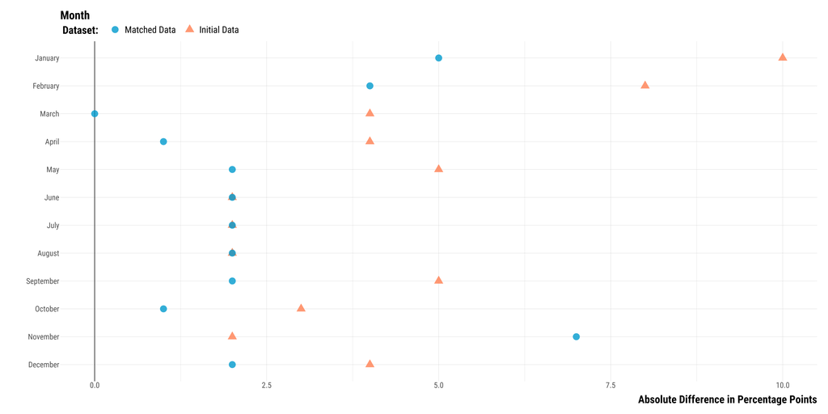

```r
# graph for month
graph_love_plot_month <- data_calendar %>%
  filter(calendar_variable == "Month") %>%
  mutate(
    values = fct_relevel(
      values,
      "January",
      "February",
      "March",
      "April",
      "May",
      "June",
      "July",
      "August",
      "September",
      "October",
      "November",
      "December"
    )
  ) %>%
  ggplot(., aes(
    y = fct_rev(values),
    x = abs_difference,
    colour = fct_rev(dataset),
    shape = fct_rev(dataset)
  )) +
  geom_vline(xintercept = 0) +
  geom_point(size = 8, alpha = 0.8) +
 scale_colour_manual(name = "Dataset:", values = c("deepskyblue3", "coral")) +
  scale_shape_manual(name = "Dataset:", values = c(16, 17)) +
  ggtitle("Month") +
  xlab("Absolute Difference in Percentage Points") +
  ylab("") +
  custom_theme +
  theme(
    legend.position = "top",
    legend.justification = "left",
    legend.direction = "horizontal"
  )

# print the plot
graph_love_plot_month
```

```r
# save the plot
ggsave(
  graph_love_plot_month,
  filename = here::here(
    "3.outputs",
    "1.figures",
    "2.analysis_pollution",
    "1.cruise_experiment",
    "1.checking_matching_procedure",
    "graph_love_plot_month.pdf"
  ),
  width = 30,
  height = 20,
  units = "cm",
  device = cairo_pdf
)
```

Plot for years:

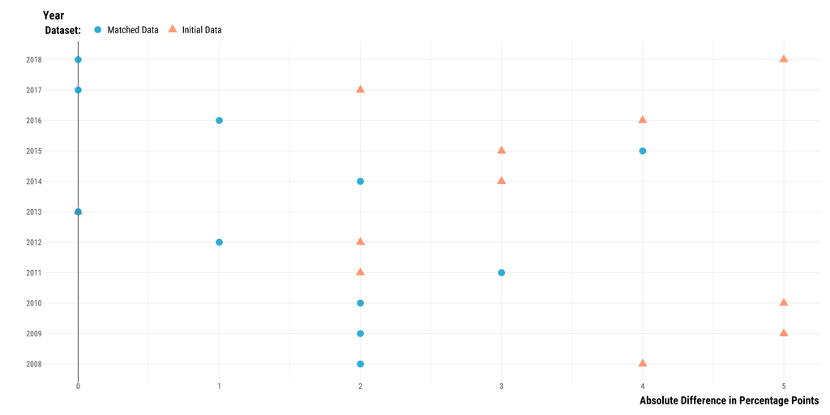

```r
# graph for year
graph_love_plot_year <- data_calendar %>%
  filter(calendar_variable == "Year") %>%
  ggplot(., aes(
    y = as.factor(as.numeric(values)),
    x = abs_difference,
    colour = fct_rev(dataset),
    shape = fct_rev(dataset)
  )) +
  geom_vline(xintercept = 0) +
  geom_point(size = 8, alpha = 0.8) +
 scale_colour_manual(name = "Dataset:", values = c("deepskyblue3", "coral")) +
  scale_shape_manual(name = "Dataset:", values = c(16, 17)) +
  ggtitle("Year") +
  xlab("Absolute Difference in Percentage Points") +
  ylab("") +
  custom_theme +
  theme(
    legend.position = "top",
    legend.justification = "left",
    legend.direction = "horizontal"
  )

# print the graph
graph_love_plot_year
```

```r
# save the plot
ggsave(
  graph_love_plot_year,
  filename = here::here(
    "3.outputs",
    "1.figures",
    "2.analysis_pollution",
    "1.cruise_experiment",
    "1.checking_matching_procedure",
    "graph_love_plot_year.pdf"
  ),
  width = 30,
  height = 20,
  units = "cm",
  device = cairo_pdf
)
```

# Overall Balance Improvement

We finally plot the distribution of standardized mean differences for continuous covariates or the absolute percentage points differences for categorical covariates between treated and control units before and after matching.

### Continuous Covariates

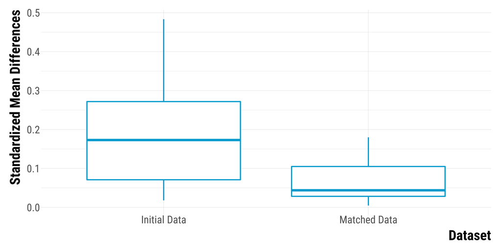

```r
# we select the dataset indicator and the standardized difference
data_love_tonnage <- data_love_tonnage %>%
  ungroup() %>%
  dplyr::filter(time < 0) %>%
  dplyr::select(dataset, standardized_difference)

data_love_pollutants <- data_love_pollutants %>%
  ungroup() %>%
  filter(time < 0) %>%
  dplyr::select(dataset, standardized_difference)

data_love_continuous_weather <- data_love_continuous_weather %>%
  ungroup() %>%
   select(dataset, standardized_difference)

data_love_road <- data_love_road %>%
  ungroup() %>%
  filter(time =="-1") %>%
  dplyr::select(dataset, standardized_difference)

data_continuous_love <-
  bind_rows(data_love_tonnage, data_love_pollutants) %>%
  bind_rows(., data_love_continuous_weather) %>%
  bind_rows(., data_love_road)

# create the graph
graph_boxplot_continuous_balance_improvement <-
  ggplot(data_continuous_love,
         aes(x = dataset, y = standardized_difference)) +
  geom_boxplot(colour = "deepskyblue3", size = 1.2) +
  scale_y_continuous(breaks = scales::pretty_breaks(n = 5)) +
  xlab("Dataset") +
  ylab("Standardized Mean Differences") +
  custom_theme +
  theme(
    # axis titles parameters
    axis.title.x = element_text(size=40, face = "bold", margin = margin(t = 20, r = 0, b = 0, l =0)),
    axis.title.y = element_text(size=40, face = "bold", margin = margin(t = 0, r = 20, b = 0, l = 0)),
    # axis texts
    axis.text.x = element_text(size=30),
    axis.text.y = element_text(size=30))

# print the graph
graph_boxplot_continuous_balance_improvement
```

```r
# save the graph
ggsave(graph_boxplot_continuous_balance_improvement, filename = here::here("3.outputs", "1.figures", "2.analysis_pollution", "1.cruise_experiment", "1.checking_matching_procedure", "graph_boxplot_continuous_balance_improvement.pdf"),
       width = 20, height = 20, units = "cm", device = cairo_pdf)
```

### Categorical Covariates

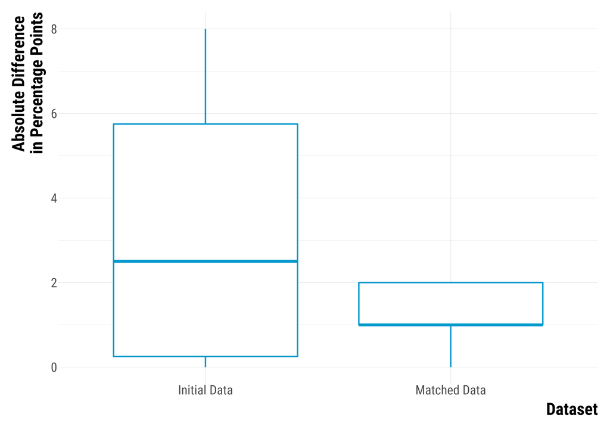

```r
# we select the dataset indicator and the standardized difference
data_calendar <- data_calendar %>%
  ungroup() %>%
  dplyr::select(dataset, abs_difference)

data_weather_categorical <- data_weather_categorical %>%
  ungroup() %>%
  filter(variable %in% c("Rainfall Dummy t", "Rainfall Dummy t-1", "Wind Direction t", "Wind Direction t-1")) %>%
  dplyr::select(dataset, abs_difference)

data_categorical_love <- bind_rows(data_calendar, data_weather_categorical)

# create the graph
graph_boxplot_categorical_balance_improvement <- ggplot(data_weather_categorical, aes(x = dataset, y = abs_difference)) +
  geom_boxplot(colour = "deepskyblue3", size = 1.2) +
  scale_y_continuous(breaks = scales::pretty_breaks(n = 5)) +
  xlab("Dataset") +
  ylab("Absolute Difference \nin Percentage Points") +
  custom_theme +
  theme(
    # axis titles parameters
    axis.title.x = element_text(size=40, face = "bold", margin = margin(t = 20, r = 0, b = 0, l =0)),
    axis.title.y = element_text(size=40, face = "bold", margin = margin(t = 0, r = 20, b = 0, l = 0)),
    # axis texts
    axis.text.x = element_text(size=30),
    axis.text.y = element_text(size=30))

# print the graph
graph_boxplot_categorical_balance_improvement
```

```r
# save the graph
ggsave(graph_boxplot_categorical_balance_improvement, filename = here::here("3.outputs", "1.figures", "2.analysis_pollution", "1.cruise_experiment", "1.checking_matching_procedure", "graph_boxplot_categorical_balance_improvement.pdf"),
       width = 20, height = 20, units = "cm", device = cairo_pdf)
```